# Project 2

## Loading packages

```python
import pandas as pd
import numpy as np
import matplotlib.pyplot as plt
import seaborn as sns
```

## Loading data

The data was downloade from https://www.kaggle.com/datasets/jjdaguirre/forbes-billionaires-2022, it containing the list of 2500+ people with fortunes valued at least 1 Billion USD, there are 2640 observations and 35 variables in the data.

```python
data = pd.read_csv("Billionaires Statistics Dataset.csv")
data.shape
```

```
(2640, 35)
```

Take a glimpse of the data.

```python
data.head()
```

|  | rank | finalWorth | category | personName | age | country | city | source | industries | countryOfCitizenship | ... | cpi_change_country | gdp_country | gross_tertiary_education_enrollment | gross_primary_education_enrollment_country | life_expectancy_country | tax_revenue_country_country | total_tax_rate_country | population_country | latitude_country | longitude_country |
| --- | --- | --- | --- | --- | --- | --- | --- | --- | --- | --- | --- | --- | --- | --- | --- | --- | --- | --- | --- | --- | --- |
| 0 | 1 | 211000 | Fashion & Retail | Bernard Arnault & family | 74.0 | France | Paris | LVMH | Fashion & Retail | France | ... | 1.1 | $2,715,518,274,227 | 65.6 | 102.5 | 82.5 | 24.2 | 60.7 | 67059887.0 | 46.227638 | 2.213749 |
| 1 | 2 | 180000 | Automotive | Elon Musk | 51.0 | United States | Austin | Tesla, SpaceX | Automotive | United States | ... | 7.5 | $21,427,700,000,000 | 88.2 | 101.8 | 78.5 | 9.6 | 36.6 | 328239523.0 | 37.090240 | -95.712891 |
| 2 | 3 | 114000 | Technology | Jeff Bezos | 59.0 | United States | Medina | Amazon | Technology | United States | ... | 7.5 | $21,427,700,000,000 | 88.2 | 101.8 | 78.5 | 9.6 | 36.6 | 328239523.0 | 37.090240 | -95.712891 |
| 3 | 4 | 107000 | Technology | Larry Ellison | 78.0 | United States | Lanai | Oracle | Technology | United States | ... | 7.5 | $21,427,700,000,000 | 88.2 | 101.8 | 78.5 | 9.6 | 36.6 | 328239523.0 | 37.090240 | -95.712891 |
| 4 | 5 | 106000 | Finance & Investments | Warren Buffett | 92.0 | United States | Omaha | Berkshire Hathaway | Finance & Investments | United States | ... | 7.5 | $21,427,700,000,000 | 88.2 | 101.8 | 78.5 | 9.6 | 36.6 | 328239523.0 | 37.090240 | -95.712891 |

5 rows × 35 columns

## Data Exploration

```python
data.info()
```

```
<class 'pandas.core.frame.DataFrame'>
RangeIndex: 2640 entries, 0 to 2639
Data columns (total 35 columns):
 #   Column                                      Non-Null Count  Dtype
---  ------                                      --------------  -----
 0   rank                                        2640 non-null   int64
 1   finalWorth                                  2640 non-null   int64
 2   category                                    2640 non-null   object
 3   personName                                  2640 non-null   object
 4   age                                         2575 non-null   float64
 5   country                                     2602 non-null   object
 6   city                                        2568 non-null   object
 7   source                                      2640 non-null   object
 8   industries                                  2640 non-null   object
 9   countryOfCitizenship                        2640 non-null   object
```

[output cut: 27 more lines]

There are missing values in some columns, with "organization", "title", "state", and "residenceStateRegion" having the most missing values. The data types include int64, float64, bool and object.

Find the find the number of mssing values in each columns.

```python
data.isna().sum()
```

```
rank                                             0
finalWorth                                       0
category                                         0
personName                                       0
age                                             65
country                                         38
city                                            72
source                                           0
industries                                       0
countryOfCitizenship                             0
organization                                  2315
selfMade                                         0
status                                           0
gender                                           0
birthDate                                       76
lastName                                         0
firstName                                        3
title                                         2301
date                                             0
state                                         1887
residenceStateRegion                          1893
birthYear                                       76
birthMonth                                      76
birthDay                                        76
cpi_country                                    184
cpi_change_country                             184
gdp_country                                    164
gross_tertiary_education_enrollment            182
gross_primary_education_enrollment_country     181
life_expectancy_country                        182
tax_revenue_country_country                    183
total_tax_rate_country                         182
population_country                             164
latitude_country                               164
longitude_country                              164
dtype: int64
```

There are missing values in several columns of the dataset. The number of missing values varies across columns, with some having a minimal number of missing values and others having a larger amount. To conduct further analysis, it is important to handle these missing values appropriately.

The column names show as below:

```python
data.columns
```

```
Index(['rank', 'finalWorth', 'category', 'personName', 'age', 'country',
       'city', 'source', 'industries', 'countryOfCitizenship', 'organization',
       'selfMade', 'status', 'gender', 'birthDate', 'lastName', 'firstName',
       'title', 'date', 'state', 'residenceStateRegion', 'birthYear',
       'birthMonth', 'birthDay', 'cpi_country', 'cpi_change_country',
       'gdp_country', 'gross_tertiary_education_enrollment',
       'gross_primary_education_enrollment_country', 'life_expectancy_country',
       'tax_revenue_country_country', 'total_tax_rate_country',
       'population_country', 'latitude_country', 'longitude_country'],
      dtype='object')
```

### Question 1

Which cities have the highest number of billionaires according to the dataset, and how do they compare to each other?

```python
top_10_cities = data.groupby("city").count()["rank"].sort_values(ascending=False).head(10)
top_10_cities
```

```
city
New York     99
Beijing      68
Hong Kong    68
Shanghai     64
London       61
Moscow       60
Mumbai       56
Shenzhen     54
Singapore    45
Delhi        37
Name: rank, dtype: int64
```

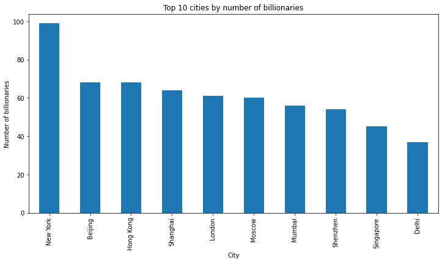

```python
plt.figure(figsize=(12, 6))
top_10_cities.plot.bar()
plt.xlabel("City")
plt.ylabel("Number of billionaries")
plt.title("Top 10 cities by number of billionaries")
plt.show()
```

### Question 2

Which countrie have the highest number of billionaires according to the dataset, and how do they compare to each other?

```python
top_10_countries = data.groupby("country").count()["rank"].sort_values(ascending=False).head(10)
top_10_countries
```

```
country
United States     754
China             523
India             157
Germany           102
United Kingdom     82
Russia             79
Switzerland        78
Hong Kong          68
Italy              55
Singapore          46
Name: rank, dtype: int64
```

[figure not shown]

```python
plt.figure(figsize=(12, 6))
top_10_cities.plot.bar()
plt.xlabel("Country")
plt.ylabel("Number of billionaries")
plt.title("Top 10 countries by number of billionaries")
plt.show()
```

The result suggests that the United States has the highest number of billionaires with 754 individuals. China comes second with 523 billionaires, followed by India with 157 billionaires. Germany, the United Kingdom, and Russia also have a significant number of billionaires, with 102, 82, and 79 individuals, respectively. Switzerland, Hong Kong, Italy, and Singapore complete the top 10 countries with 78, 68, 55, and 46 billionaires, respectively.

## Question 3

What is the distribution of age for these billionaries, is there any difference between female and male?

```python
data.groupby("gender").median()["age"]
```

```
gender
F    63.0
M    65.0
Name: age, dtype: float64
```

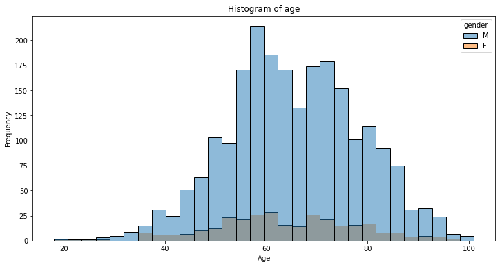

```python
plt.figure(figsize=(12, 6))
sns.histplot(data=data, x="age", hue="gender")
plt.xlabel("Age")
plt.ylabel("Frequency")
plt.title("Histogram of age")
plt.show()
```

As we can see from the histogram, the distribution of age is approximte symmetric, the distribution of the age is quite similar for male and female, The median age of male is larger than the median age of female.

## Question 4

Which industry has the largest number of billionaries?

```python
num_by_industries = data.groupby("industries").count()["rank"].sort_values(ascending=False)
num_by_industries
```

```
industries
Finance & Investments         372
Manufacturing                 324
Technology                    314
Fashion & Retail              266
Food & Beverage               212
Healthcare                    201
Real Estate                   193
Diversified                   187
Energy                        100
Media & Entertainment          91
Metals & Mining                74
Automotive                     73
Service                        53
Construction & Engineering     45
Logistics                      40
Sports                         39
Telecom                        31
Gambling & Casinos             25
Name: rank, dtype: int64
```

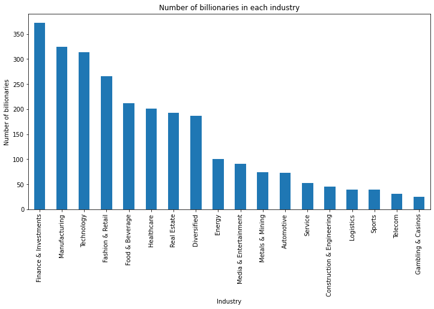

```python
plt.figure(figsize=(12, 6))
num_by_industries.plot.bar()
plt.xlabel("Industry")
plt.ylabel("Number of billionaries")
plt.title("Number of billionaries in each industry")
plt.show()
```

From the above output, we can conclude that the finance and investments industry has the largest number of billionaires with 372 individuals, followed by manufacturing with 324 individuals, and technology with 314 individuals. The gambling and casinos industry has the smallest number of billionaires with only 25 individuals. These findings suggest that the finance and investment industry is a lucrative area for generating wealth and attracting high net worth individuals, while the gambling and casinos industry is less attractive in terms of producing billionaires. This information may be useful for investors and entrepreneurs looking to enter or invest in different industries.

## Question 5

What is the distribution of age for each industries? Is there any indsutry have younger billionaries?

```python
data.groupby("industries").median()["age"].sort_values()
```

```
industries
Technology                    57.0
Metals & Mining               61.0
Manufacturing                 63.0
Healthcare                    64.0
Construction & Engineering    64.5
Automotive                    65.0
Finance & Investments         65.0
Energy                        67.0
Telecom                       67.0
Food & Beverage               68.0
Logistics                     68.0
Media & Entertainment         68.0
Diversified                   68.5
Fashion & Retail              69.0
Real Estate                   69.0
Service                       69.0
Gambling & Casinos            71.0
Sports                        71.0
Name: age, dtype: float64
```

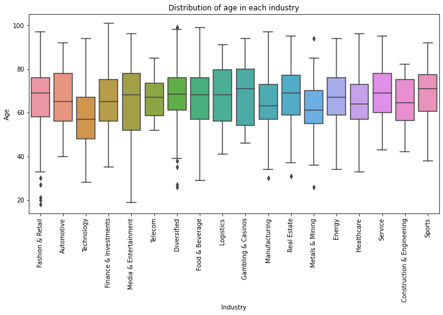

```python
plt.figure(figsize=(12, 6))
sns.boxplot(data=data, x="industries", y="age")
plt.xlabel("Industry")
plt.ylabel("Age")
plt.xticks(rotation=90)
plt.title("Distribution of age in each industry")
plt.show()
```

The distribution of billionaires' ages across different industries reveals notable variations. The median age of billionaires in the Technology industry is comparatively lower at 57 years, indicating a higher concentration of younger individuals in this sector. On the other hand, industries such as Sports and Gambling & Casinos have the highest median ages at 71 years, suggesting a higher prevalence of older individuals within these sectors. This implies that the Technology industry seems to have a higher representation of younger billionaires compared to other industries, possibly reflecting the rapid wealth accumulation and entrepreneurial success seen in the tech sector in recent years. Conversely, industries such as Sports and Gambling & Casinos may have a more established or traditional base, leading to a higher median age among billionaires.

## Question 6

Which industry have the largest total worth?

```python
data.groupby("industries").sum()["finalWorth"].sort_values(ascending=False)
```

```
industries
Technology                    1877900
Fashion & Retail              1698800
Finance & Investments         1605100
Manufacturing                 1019000
Food & Beverage                957200
Diversified                    905200
Real Estate                    657400
Healthcare                     643200
Automotive                     525300
Energy                         453500
Metals & Mining                446800
Media & Entertainment          427500
Logistics                      239500
Telecom                        203500
Service                        173400
Sports                         134500
Gambling & Casinos             120500
Construction & Engineering     118500
Name: finalWorth, dtype: int64
```

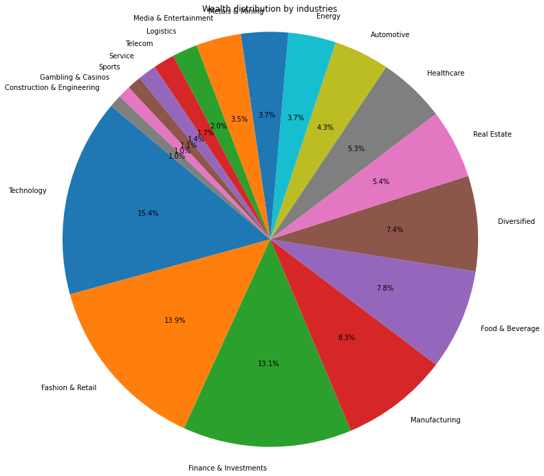

```python
grouped_data = data.groupby("industries").sum()["finalWorth"].sort_values(ascending=False)

# Plotting the pie chart
plt.figure(figsize=(12, 12))
plt.pie(grouped_data, labels=grouped_data.index, autopct='%1.1f%%', startangle=140)
plt.axis('equal')  # Equal aspect ratio ensures that pie is drawn as a circle.
plt.title('Wealth distribution by industries')

# Show the pie chart
plt.show()
```

### Question 7

Which numeric variables are associated with the final worth?

```python
corr = data[["finalWorth", 'cpi_country', 'cpi_change_country',
       'gdp_country', 'gross_tertiary_education_enrollment',
       'gross_primary_education_enrollment_country', 'life_expectancy_country',
       'tax_revenue_country_country', 'total_tax_rate_country',
       'population_country']].corr()
corr
```

|  | finalWorth | cpi_country | cpi_change_country | gross_tertiary_education_enrollment | gross_primary_education_enrollment_country | life_expectancy_country | tax_revenue_country_country | total_tax_rate_country | population_country |
| --- | --- | --- | --- | --- | --- | --- | --- | --- | --- |
| finalWorth | 1.000000 | -0.042842 | 0.035702 | 0.066711 | -0.008880 | 0.021819 | -0.009270 | -0.036381 | -0.053024 |
| cpi_country | -0.042842 | 1.000000 | 0.436769 | -0.456428 | 0.279601 | -0.747716 | -0.037022 | 0.245961 | 0.218303 |
| cpi_change_country | 0.035702 | 0.436769 | 1.000000 | 0.167455 | 0.053483 | -0.393884 | -0.317516 | 0.003272 | 0.066501 |
| gross_tertiary_education_enrollment | 0.066711 | -0.456428 | 0.167455 | 1.000000 | -0.298473 | 0.523931 | 0.028123 | -0.393902 | -0.543031 |
| gross_primary_education_enrollment_country | -0.008880 | 0.279601 | 0.053483 | -0.298473 | 1.000000 | -0.306788 | 0.129724 | 0.098344 | 0.009805 |
| life_expectancy_country | 0.021819 | -0.747716 | -0.393884 | 0.523931 | -0.306788 | 1.000000 | 0.357407 | -0.268434 | -0.520740 |
| tax_revenue_country_country | -0.009270 | -0.037022 | -0.317516 | 0.028123 | 0.129724 | 0.357407 | 1.000000 | -0.049343 | -0.431112 |
| total_tax_rate_country | -0.036381 | 0.245961 | 0.003272 | -0.393902 | 0.098344 | -0.268434 | -0.049343 | 1.000000 | 0.644155 |
| population_country | -0.053024 | 0.218303 | 0.066501 | -0.543031 | 0.009805 | -0.520740 | -0.431112 | 0.644155 | 1.000000 |

## Question 8

Is there a linear relationship between the cpi and life expectancy?

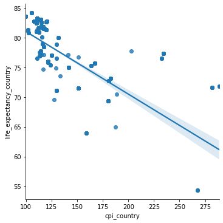

```python
sns.lmplot(data=data, x="cpi_country",y="life_expectancy_country")
```

```python
import statsmodels.api as sm
df = data[["country", "cpi_country", "life_expectancy_country"]].dropna()
df = df.drop_duplicates()
X = df["cpi_country"]
y = df["life_expectancy_country"]
X = sm.add_constant(X)  # Add a constant to the independent variable
model = sm.OLS(y, X).fit()
model.summary()
```

OLS Regression Results

| Dep. Variable: | life_expectancy_country | R-squared: | 0.421 |
| --- | --- | --- | --- |
| Model: | OLS | Adj. R-squared: | 0.412 |
| Method: | Least Squares | F-statistic: | 45.12 |
| Date: | Fri, 08 Dec 2023 | Prob (F-statistic): | 6.63e-09 |
| Time: | 13:28:30 | Log-Likelihood: | -181.14 |
| No. Observations: | 64 | AIC: | 366.3 |
| Df Residuals: | 62 | BIC: | 370.6 |
| Df Model: | 1 |  |  |
| Covariance Type: | nonrobust |  |  |

|  | coef | std err | t | P>\|t\| | [0.025 | 0.975] |
| --- | --- | --- | --- | --- | --- | --- |
| const | 88.5529 | 1.749 | 50.621 | 0.000 | 85.056 | 92.050 |
| cpi_country | -0.0810 | 0.012 | -6.717 | 0.000 | -0.105 | -0.057 |

| Omnibus: | 9.957 | Durbin-Watson: | 2.165 |
| --- | --- | --- | --- |
| Prob(Omnibus): | 0.007 | Jarque-Bera (JB): | 9.717 |
| Skew: | -0.828 | Prob(JB): | 0.00776 |
| Kurtosis: | 3.949 | Cond. No. | 487. |

Notes:  
[1] Standard Errors assume that the covariance matrix of the errors is correctly specified.

The model's summary indicates that there is a statistically significant relationship between the CPI (Consumer Price Index) of a country and its life expectancy. The R-squared value of 0.421 suggests that approximately 42.1% of the variation in life expectancy can be explained by changes in the CPI. The negative coefficient for the CPI variable (-0.0810) implies that as the CPI increases, life expectancy tends to decrease. This relationship is supported by the p-value of 0.000, indicating that the coefficient is significantly different from zero.

The constant term in the model is 88.5529, which represents the estimated life expectancy when the CPI is zero. However, since the CPI cannot be zero in practice, this value should be interpreted with caution. The coefficient of -0.0810 for the CPI variable means that for every one unit increase in the CPI, the life expectancy decreases by approximately 0.0810 years.

Overall, based on this model, we can infer that there is a negative linear relationship between the CPI and life expectancy. Higher levels of inflation, as measured by the CPI, are associated with lower life expectancy. However, it's important to note that correlation does not imply causation, and there may be other factors not considered in this model that also influence life expectancy.

## Conclusion

In further work, we can explore additional variables or factors that may contribute to the wealth accumulation and success of billionaires. This could include analyzing the impact of educational background, entrepreneurial experience, or specific market trends on individual wealth.